# Checks on the Bayesian Hierarchical Models

Kristian Brock

16 September, 2019

```r
# This script in the root of the project loads the datasets
source('../../../Load.R')

library(brms)
library(ggplot2)
```

## DLT Model

```r
dlt_mod <- readRDS('dlt_mod.rds')
```

```r
dlt_mod
```

```
 Family: binomial
  Links: mu = logit
Formula: Events | trials(n) ~ 1 + DoseLevel + FixedDoseChemo + Source + Source:DoseLevel + HaemNonhaem + HaemNonhaem:DoseLevel + (1 + DoseLevel | AnalysisSeriesId) + (1 + DoseLevel | DoseVaryingTreatmentType)
   Data: dlt %>% left_join(studies, by = "Study") %>% left_ (Number of observations: 637)
Samples: 4 chains, each with iter = 3000; warmup = 1500; thin = 1;
         total post-warmup samples = 6000

Group-Level Effects:
~AnalysisSeriesId (Number of levels: 154)
                         Estimate Est.Error l-95% CI u-95% CI Eff.Sample Rhat
sd(Intercept)                0.91      0.12     0.68     1.16       2058 1.00
sd(DoseLevel)                0.46      0.10     0.28     0.66       1878 1.00
cor(Intercept,DoseLevel)     0.49      0.22     0.03     0.89       1596 1.00

~DoseVaryingTreatmentType (Number of levels: 15)
                         Estimate Est.Error l-95% CI u-95% CI Eff.Sample Rhat
sd(Intercept)                0.53      0.31     0.05     1.26       1223 1.00
sd(DoseLevel)                0.25      0.19     0.01     0.72       1753 1.00
cor(Intercept,DoseLevel)     0.21      0.54    -0.87     0.97       2798 1.00

Population-Level Effects:
                                       Estimate Est.Error l-95% CI u-95% CI Eff.Sample Rhat
Intercept                                 -3.12      0.75    -4.66    -1.73       2900 1.00
DoseLevel                                  1.51      0.56     0.46     2.67       2164 1.00
FixedDoseChemo                             0.27      0.26    -0.25     0.78       3094 1.00
SourceChiuzanRuleBased1                   -0.26      0.26    -0.78     0.25       2469 1.00
HaemNonhaemHaematological                  0.78      0.75    -0.62     2.33       2983 1.00
HaemNonhaemNonHaematological               0.72      0.72    -0.61     2.21       2973 1.00
DoseLevel:SourceChiuzanRuleBased1         -0.19      0.17    -0.53     0.16       4522 1.00
DoseLevel:HaemNonhaemHaematological       -0.61      0.56    -1.74     0.43       2194 1.00
DoseLevel:HaemNonhaemNonHaematological    -0.80      0.55    -1.90     0.21       2197 1.00

Samples were drawn using sampling(NUTS). For each parameter, Eff.Sample
is a crude measure of effective sample size, and Rhat is the potential
scale reduction factor on split chains (at convergence, Rhat = 1).
```

Rhats and Eff.Samples look fine. No divergent transitions or violations of max tree-depth are reported.

```
Using 10 posterior samples for ppc type 'dens_overlay' by default.
```

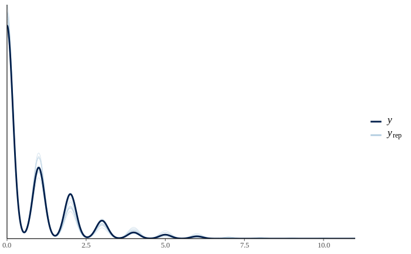

```r
pp_check(dlt_mod)
```

The x-axis is the sampled number of DLTs, conditional on the number of attempts, using all of the DLT series. Posterior samples are a faithful representation of the observed data.

Distribution of series-level intercepts:

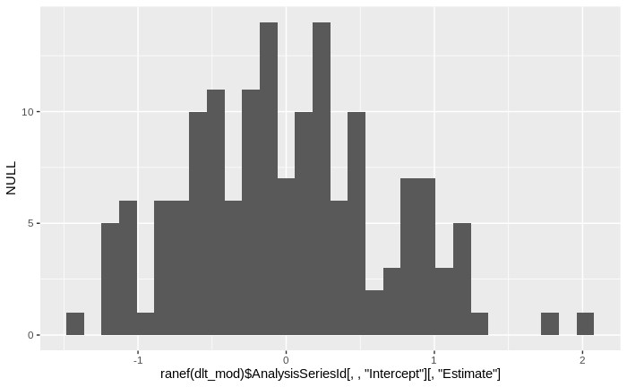

```r
qplot(ranef(dlt_mod)$AnalysisSeriesId[, , 'Intercept'][,'Estimate'],
      geom = 'histogram')
```

Normal enough.

Distribution of series-level gradients for DoseLevel:

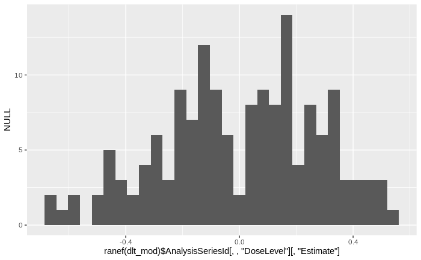

```r
qplot(ranef(dlt_mod)$AnalysisSeriesId[, , 'DoseLevel'][,'Estimate'],
      geom = 'histogram')
```

Bit of a negative skew but not alarmingly non-normal.

Distribution of series-level intercepts:

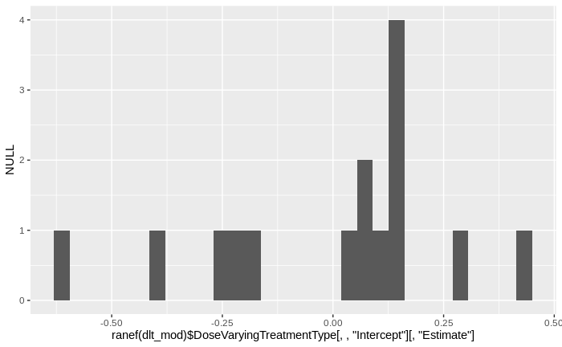

```r
qplot(ranef(dlt_mod)$DoseVaryingTreatmentType[, , 'Intercept'][,'Estimate'],
      geom = 'histogram')
```

There are not many of these but the fit to normal is not terrible

Distribution of series-level gradients for DoseLevel:

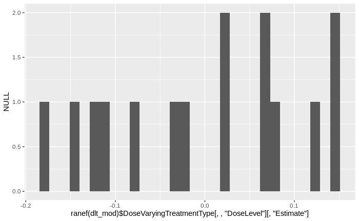

```r
qplot(ranef(dlt_mod)$DoseVaryingTreatmentType[, , 'DoseLevel'][,'Estimate'],
      geom = 'histogram')
```

There are not many of these but the fit to normal is not terrible.

## Objective Response Model

```r
obj_resp_mod <- readRDS('obj_resp_mod.rds')
```

```r
obj_resp_mod
```

```
 Family: binomial
  Links: mu = logit
Formula: Events | trials(n) ~ 1 + DoseLevel + FixedDoseChemo + Source + Source:DoseLevel + HaemNonhaem + HaemNonhaem:DoseLevel + (1 + DoseLevel | AnalysisSeriesId) + (1 + DoseLevel | DoseVaryingTreatmentType)
   Data: obj_resp %>% left_join(studies, by = "Study") %>%  (Number of observations: 372)
Samples: 4 chains, each with iter = 3000; warmup = 1500; thin = 1;
         total post-warmup samples = 6000

Group-Level Effects:
~AnalysisSeriesId (Number of levels: 93)
                         Estimate Est.Error l-95% CI u-95% CI Eff.Sample Rhat
sd(Intercept)                2.04      0.26     1.59     2.61       1915 1.00
sd(DoseLevel)                0.17      0.11     0.01     0.42       2048 1.00
cor(Intercept,DoseLevel)     0.04      0.48    -0.88     0.90       5504 1.00

~DoseVaryingTreatmentType (Number of levels: 12)
                         Estimate Est.Error l-95% CI u-95% CI Eff.Sample Rhat
sd(Intercept)                1.33      0.79     0.15     3.28       1577 1.00
sd(DoseLevel)                0.24      0.19     0.01     0.70       2768 1.00
cor(Intercept,DoseLevel)    -0.17      0.56    -0.97     0.89       4067 1.00

Population-Level Effects:
                                       Estimate Est.Error l-95% CI u-95% CI Eff.Sample Rhat
Intercept                                 -4.10      1.42    -7.00    -1.42       2459 1.00
DoseLevel                                  0.33      0.42    -0.49     1.17       3184 1.00
FixedDoseChemo                             2.15      0.67     0.84     3.51       1979 1.00
SourceChiuzanRuleBased1                    0.09      0.63    -1.19     1.30       2126 1.00
HaemNonhaemHaematological                  2.99      1.37     0.33     5.68       2174 1.00
HaemNonhaemNonHaematological               0.29      1.27    -2.20     2.80       2374 1.00
DoseLevel:SourceChiuzanRuleBased1         -0.12      0.18    -0.48     0.24       6573 1.00
DoseLevel:HaemNonhaemHaematological        0.04      0.41    -0.77     0.85       3460 1.00
DoseLevel:HaemNonhaemNonHaematological    -0.25      0.38    -1.00     0.49       3485 1.00

Samples were drawn using sampling(NUTS). For each parameter, Eff.Sample
is a crude measure of effective sample size, and Rhat is the potential
scale reduction factor on split chains (at convergence, Rhat = 1).
```

Rhats and Eff.Samples look fine. No divergent transitions or violations of max tree-depth are reported.

```
Using 10 posterior samples for ppc type 'dens_overlay' by default.
```

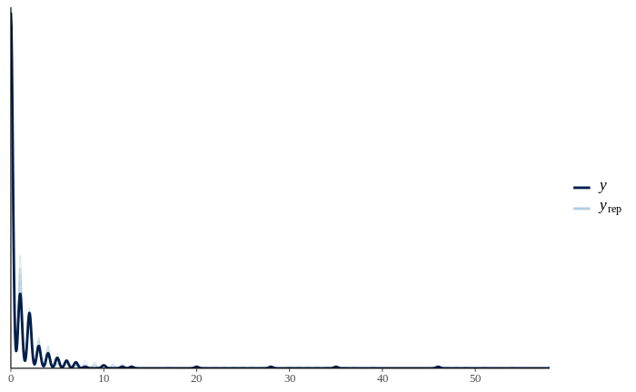

```r
pp_check(obj_resp_mod)
```

The x-axis is the sampled number of responses, conditional on the number of attempts, using all of the response series. Posterior samples are a faithful representation of the observed data.

Distribution of series-level intercepts:

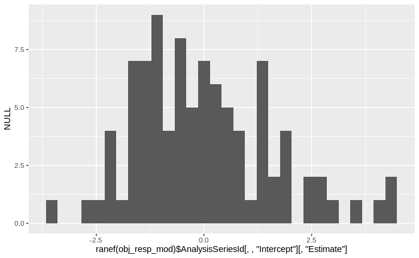

```r
qplot(ranef(obj_resp_mod)$AnalysisSeriesId[, , 'Intercept'][,'Estimate'],
      geom = 'histogram')
```

Mostly normal.

Distribution of series-level gradients for DoseLevel:

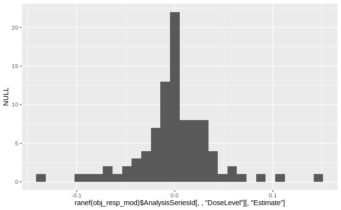

```r
qplot(ranef(obj_resp_mod)$AnalysisSeriesId[, , 'DoseLevel'][,'Estimate'],
      geom = 'histogram')
```

Long tails but not alarmingly non-normal.

Distribution of series-level intercepts:

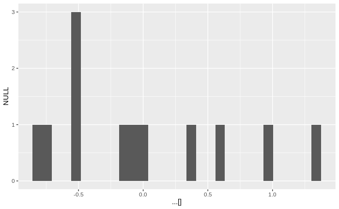

```r
qplot(ranef(obj_resp_mod)$DoseVaryingTreatmentType[, , 'Intercept'][,'Estimate'],
      geom = 'histogram')
```

Hmm.

Distribution of series-level gradients for DoseLevel:

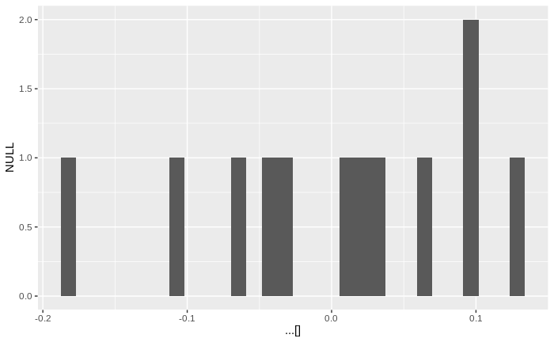

```r
qplot(ranef(obj_resp_mod)$DoseVaryingTreatmentType[, , 'DoseLevel'][,'Estimate'],
      geom = 'histogram')
```

Normal is not a poor working model.